# Risk Factor Analysis

## Outcome Variable

**Outcome Variable:** pers_wast

## Predictor Variables

**Intervention Variable:** gagebrth

**Adjustment Set:**

- arm
- sex
- W_mage
- W_fage
- meducyrs
- feducyrs
- single
- brthmon
- delta_W_mage
- delta_W_fage
- delta_meducyrs
- delta_feducyrs
- delta_single
- delta_brthmon

## Stratifying Variables

The analysis was stratified on these variable(s):

- agecat
- studyid
- country

## Data Summary

| agecat | studyid | country | gagebrth | pers_wast | n_cell | n |
| --- | --- | --- | --- | --- | --- | --- |
| 0-24 months | ki1000108-CMC-V-BCS-2002 | INDIA | Full or late term | 0 | 201 | 351 |
| 0-24 months | ki1000108-CMC-V-BCS-2002 | INDIA | Full or late term | 1 | 14 | 351 |
| 0-24 months | ki1000108-CMC-V-BCS-2002 | INDIA | Preterm | 0 | 49 | 351 |
| 0-24 months | ki1000108-CMC-V-BCS-2002 | INDIA | Preterm | 1 | 3 | 351 |
| 0-24 months | ki1000108-CMC-V-BCS-2002 | INDIA | Early term | 0 | 81 | 351 |
| 0-24 months | ki1000108-CMC-V-BCS-2002 | INDIA | Early term | 1 | 3 | 351 |
| 0-24 months | ki1000108-IRC | INDIA | Full or late term | 0 | 225 | 390 |
| 0-24 months | ki1000108-IRC | INDIA | Full or late term | 1 | 25 | 390 |
| 0-24 months | ki1000108-IRC | INDIA | Preterm | 0 | 34 | 390 |
| 0-24 months | ki1000108-IRC | INDIA | Preterm | 1 | 8 | 390 |
| 0-24 months | ki1000108-IRC | INDIA | Early term | 0 | 85 | 390 |
| 0-24 months | ki1000108-IRC | INDIA | Early term | 1 | 13 | 390 |
| 0-24 months | ki1000109-EE | PAKISTAN | Full or late term | 0 | 24 | 377 |
| 0-24 months | ki1000109-EE | PAKISTAN | Full or late term | 1 | 1 | 377 |
| 0-24 months | ki1000109-EE | PAKISTAN | Preterm | 0 | 225 | 377 |
| 0-24 months | ki1000109-EE | PAKISTAN | Preterm | 1 | 19 | 377 |
| 0-24 months | ki1000109-EE | PAKISTAN | Early term | 0 | 100 | 377 |
| 0-24 months | ki1000109-EE | PAKISTAN | Early term | 1 | 8 | 377 |
| 0-24 months | ki1000304b-SAS-CompFeed | INDIA | Full or late term | 0 | 24 | 1358 |
| 0-24 months | ki1000304b-SAS-CompFeed | INDIA | Full or late term | 1 | 2 | 1358 |
| 0-24 months | ki1000304b-SAS-CompFeed | INDIA | Preterm | 0 | 1134 | 1358 |
| 0-24 months | ki1000304b-SAS-CompFeed | INDIA | Preterm | 1 | 104 | 1358 |
| 0-24 months | ki1000304b-SAS-CompFeed | INDIA | Early term | 0 | 87 | 1358 |
| 0-24 months | ki1000304b-SAS-CompFeed | INDIA | Early term | 1 | 7 | 1358 |
| 0-24 months | ki1017093c-NIH-Crypto | BANGLADESH | Full or late term | 0 | 156 | 730 |
| 0-24 months | ki1017093c-NIH-Crypto | BANGLADESH | Full or late term | 1 | 2 | 730 |
| 0-24 months | ki1017093c-NIH-Crypto | BANGLADESH | Preterm | 0 | 241 | 730 |
| 0-24 months | ki1017093c-NIH-Crypto | BANGLADESH | Preterm | 1 | 14 | 730 |
| 0-24 months | ki1017093c-NIH-Crypto | BANGLADESH | Early term | 0 | 307 | 730 |
| 0-24 months | ki1017093c-NIH-Crypto | BANGLADESH | Early term | 1 | 10 | 730 |

[output cut: 168 more lines]

The following strata were considered:

- agecat: 0-24 months, studyid: ki1000108-CMC-V-BCS-2002, country: INDIA
- agecat: 0-24 months, studyid: ki1000108-IRC, country: INDIA
- agecat: 0-24 months, studyid: ki1000109-EE, country: PAKISTAN
- agecat: 0-24 months, studyid: ki1000304b-SAS-CompFeed, country: INDIA
- agecat: 0-24 months, studyid: ki1017093c-NIH-Crypto, country: BANGLADESH
- agecat: 0-24 months, studyid: ki1066203-TanzaniaChild2, country: TANZANIA, UNITED REPUBLIC OF
- agecat: 0-24 months, studyid: ki1101329-Keneba, country: GAMBIA
- agecat: 0-24 months, studyid: ki1119695-PROBIT, country: BELARUS
- agecat: 0-24 months, studyid: ki1135781-COHORTS, country: GUATEMALA
- agecat: 0-24 months, studyid: ki1135781-COHORTS, country: INDIA
- agecat: 0-24 months, studyid: ki1135781-COHORTS, country: PHILIPPINES
- agecat: 0-24 months, studyid: kiGH5241-JiVitA-3, country: BANGLADESH
- agecat: 0-6 months, studyid: ki1000108-CMC-V-BCS-2002, country: INDIA
- agecat: 0-6 months, studyid: ki1000108-IRC, country: INDIA
- agecat: 0-6 months, studyid: ki1000109-EE, country: PAKISTAN
- agecat: 0-6 months, studyid: ki1017093c-NIH-Crypto, country: BANGLADESH
- agecat: 0-6 months, studyid: ki1066203-TanzaniaChild2, country: TANZANIA, UNITED REPUBLIC OF
- agecat: 0-6 months, studyid: ki1101329-Keneba, country: GAMBIA
- agecat: 0-6 months, studyid: ki1119695-PROBIT, country: BELARUS
- agecat: 0-6 months, studyid: ki1135781-COHORTS, country: PHILIPPINES
- agecat: 0-6 months, studyid: kiGH5241-JiVitA-3, country: BANGLADESH
- agecat: 6-24 months, studyid: ki1000108-CMC-V-BCS-2002, country: INDIA
- agecat: 6-24 months, studyid: ki1000108-IRC, country: INDIA
- agecat: 6-24 months, studyid: ki1000109-EE, country: PAKISTAN
- agecat: 6-24 months, studyid: ki1000304b-SAS-CompFeed, country: INDIA
- agecat: 6-24 months, studyid: ki1017093c-NIH-Crypto, country: BANGLADESH
- agecat: 6-24 months, studyid: ki1066203-TanzaniaChild2, country: TANZANIA, UNITED REPUBLIC OF
- agecat: 6-24 months, studyid: ki1101329-Keneba, country: GAMBIA
- agecat: 6-24 months, studyid: ki1119695-PROBIT, country: BELARUS
- agecat: 6-24 months, studyid: ki1135781-COHORTS, country: GUATEMALA
- agecat: 6-24 months, studyid: ki1135781-COHORTS, country: INDIA
- agecat: 6-24 months, studyid: ki1135781-COHORTS, country: PHILIPPINES
- agecat: 6-24 months, studyid: kiGH5241-JiVitA-3, country: BANGLADESH

### Dropped Strata

Some strata were dropped due to rare outcomes:

- agecat: 0-24 months, studyid: ki1000108-CMC-V-BCS-2002, country: INDIA
- agecat: 0-24 months, studyid: ki1000109-EE, country: PAKISTAN
- agecat: 0-24 months, studyid: ki1000304b-SAS-CompFeed, country: INDIA
- agecat: 0-24 months, studyid: ki1017093c-NIH-Crypto, country: BANGLADESH
- agecat: 0-6 months, studyid: ki1000109-EE, country: PAKISTAN
- agecat: 0-6 months, studyid: ki1017093c-NIH-Crypto, country: BANGLADESH
- agecat: 0-6 months, studyid: kiGH5241-JiVitA-3, country: BANGLADESH
- agecat: 6-24 months, studyid: ki1000108-CMC-V-BCS-2002, country: INDIA
- agecat: 6-24 months, studyid: ki1000109-EE, country: PAKISTAN
- agecat: 6-24 months, studyid: ki1000304b-SAS-CompFeed, country: INDIA
- agecat: 6-24 months, studyid: ki1017093c-NIH-Crypto, country: BANGLADESH

## Methods Detail

We’re interested in the causal parameters $E[Y_a]$ for all values of $a \in \mathcal{A}$. These parameters represent the mean outcome if, possibly contrary to fact, we intervened to set all units to have $A=a$. Under the randomization and positivity assumptions, these are identified by the statistical parameters $\psi_a=E_W[E_{Y|A,W}(Y|A=a,W)]$. In addition, we’re interested in the mean of $Y$, $E[Y]$ under no intervention (the observed mean). We will estimate these parameters by using SuperLearner to fit the relevant likelihood factors – $E_{Y|A,W}(Y|A=a,W)$ and $p(A=a|W)$, and then updating our likelihood fit using a joint TMLE.

For unadjusted analyses ($W=\{\}$), initial likelihoods were estimated using Lrnr_glm to estimate the simple $E(Y|A)$ and Lrnr_mean to estimate $p(A)$. For adjusted analyses, a small library containing Lrnr_glmnet, Lrnr_xgboost, and Lrnr_mean was used.

Having estimated these parameters, we will then use the delta method to estimate relative risks and attributable risks relative to a prespecified baseline level of $A$.

# Results Detail

## Results Plots

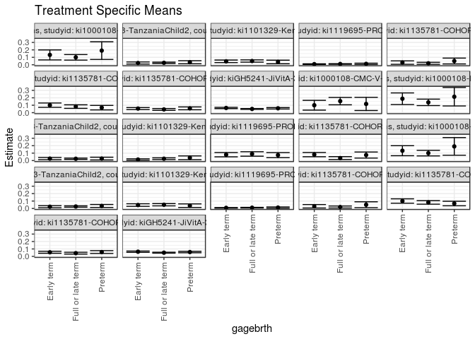

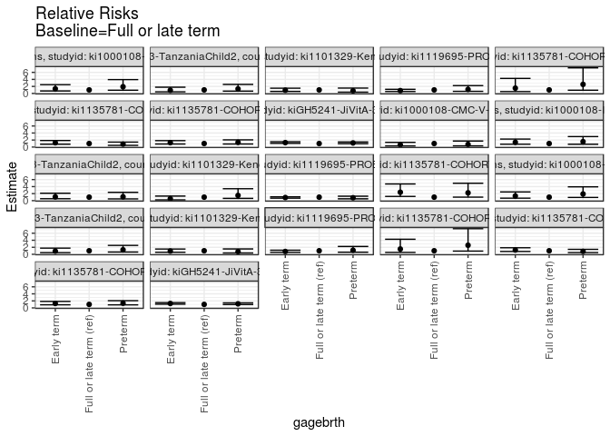

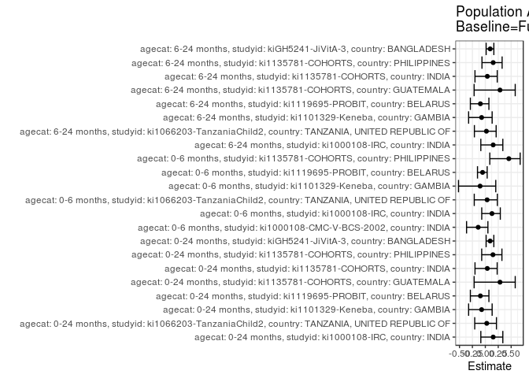

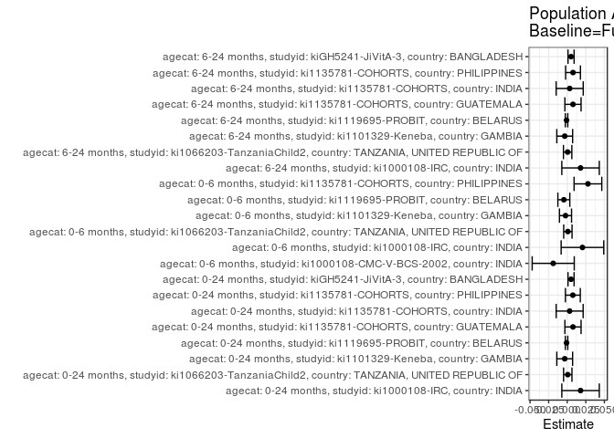

## Results Table

### Parameter: TSM

| agecat | studyid | country | intervention_level | baseline_level | estimate | ci_lower | ci_upper |
| --- | --- | --- | --- | --- | --- | --- | --- |
| 0-24 months | ki1000108-IRC | INDIA | Full or late term | NA | 0.1000000 | 0.0627645 | 0.1372355 |
| 0-24 months | ki1000108-IRC | INDIA | Preterm | NA | 0.1904762 | 0.0715668 | 0.3093856 |
| 0-24 months | ki1000108-IRC | INDIA | Early term | NA | 0.1326531 | 0.0654100 | 0.1998961 |
| 0-24 months | ki1066203-TanzaniaChild2 | TANZANIA, UNITED REPUBLIC OF | Full or late term | NA | 0.0262807 | 0.0173662 | 0.0351952 |
| 0-24 months | ki1066203-TanzaniaChild2 | TANZANIA, UNITED REPUBLIC OF | Preterm | NA | 0.0340307 | 0.0138437 | 0.0542176 |
| 0-24 months | ki1066203-TanzaniaChild2 | TANZANIA, UNITED REPUBLIC OF | Early term | NA | 0.0235689 | 0.0096468 | 0.0374910 |
| 0-24 months | ki1101329-Keneba | GAMBIA | Full or late term | NA | 0.0503226 | 0.0349267 | 0.0657185 |
| 0-24 months | ki1101329-Keneba | GAMBIA | Preterm | NA | 0.0376569 | 0.0135148 | 0.0617990 |
| 0-24 months | ki1101329-Keneba | GAMBIA | Early term | NA | 0.0462633 | 0.0288913 | 0.0636354 |
| 0-24 months | ki1119695-PROBIT | BELARUS | Full or late term | NA | 0.0105052 | 0.0058392 | 0.0151712 |
| 0-24 months | ki1119695-PROBIT | BELARUS | Preterm | NA | 0.0120690 | 0.0030561 | 0.0210818 |
| 0-24 months | ki1119695-PROBIT | BELARUS | Early term | NA | 0.0083676 | 0.0038455 | 0.0128898 |
| 0-24 months | ki1135781-COHORTS | GUATEMALA | Full or late term | NA | 0.0195599 | 0.0061299 | 0.0329899 |
| 0-24 months | ki1135781-COHORTS | GUATEMALA | Preterm | NA | 0.0504202 | 0.0110797 | 0.0897606 |
| 0-24 months | ki1135781-COHORTS | GUATEMALA | Early term | NA | 0.0294118 | 0.0062107 | 0.0526128 |
| 0-24 months | ki1135781-COHORTS | INDIA | Full or late term | NA | 0.0818813 | 0.0581377 | 0.1056249 |
| 0-24 months | ki1135781-COHORTS | INDIA | Preterm | NA | 0.0675182 | 0.0371022 | 0.0979342 |
| 0-24 months | ki1135781-COHORTS | INDIA | Early term | NA | 0.1009307 | 0.0716851 | 0.1301764 |
| 0-24 months | ki1135781-COHORTS | PHILIPPINES | Full or late term | NA | 0.0436941 | 0.0315350 | 0.0558531 |
| 0-24 months | ki1135781-COHORTS | PHILIPPINES | Preterm | NA | 0.0581444 | 0.0390796 | 0.0772093 |
| 0-24 months | ki1135781-COHORTS | PHILIPPINES | Early term | NA | 0.0550401 | 0.0416123 | 0.0684678 |
| 0-24 months | kiGH5241-JiVitA-3 | BANGLADESH | Full or late term | NA | 0.0500905 | 0.0439825 | 0.0561985 |
| 0-24 months | kiGH5241-JiVitA-3 | BANGLADESH | Preterm | NA | 0.0586136 | 0.0488449 | 0.0683824 |
| 0-24 months | kiGH5241-JiVitA-3 | BANGLADESH | Early term | NA | 0.0631901 | 0.0544324 | 0.0719478 |
| 0-6 months | ki1000108-CMC-V-BCS-2002 | INDIA | Full or late term | NA | 0.1553398 | 0.1058014 | 0.2048782 |
| 0-6 months | ki1000108-CMC-V-BCS-2002 | INDIA | Preterm | NA | 0.1176471 | 0.0290906 | 0.2062035 |
| 0-6 months | ki1000108-CMC-V-BCS-2002 | INDIA | Early term | NA | 0.1000000 | 0.0341631 | 0.1658369 |
| 0-6 months | ki1000108-IRC | INDIA | Full or late term | NA | 0.1387755 | 0.0954297 | 0.1821213 |
| 0-6 months | ki1000108-IRC | INDIA | Preterm | NA | 0.2142857 | 0.0900289 | 0.3385425 |
| 0-6 months | ki1000108-IRC | INDIA | Early term | NA | 0.1875000 | 0.1093206 | 0.2656794 |
| 0-6 months | ki1066203-TanzaniaChild2 | TANZANIA, UNITED REPUBLIC OF | Full or late term | NA | 0.0244519 | 0.0156597 | 0.0332442 |
| 0-6 months | ki1066203-TanzaniaChild2 | TANZANIA, UNITED REPUBLIC OF | Preterm | NA | 0.0268456 | 0.0084896 | 0.0452017 |
| 0-6 months | ki1066203-TanzaniaChild2 | TANZANIA, UNITED REPUBLIC OF | Early term | NA | 0.0266667 | 0.0117775 | 0.0415558 |
| 0-6 months | ki1101329-Keneba | GAMBIA | Full or late term | NA | 0.0251479 | 0.0133406 | 0.0369552 |
| 0-6 months | ki1101329-Keneba | GAMBIA | Preterm | NA | 0.0373832 | 0.0119582 | 0.0628082 |
| 0-6 months | ki1101329-Keneba | GAMBIA | Early term | NA | 0.0136986 | 0.0036169 | 0.0237804 |
| 0-6 months | ki1119695-PROBIT | BELARUS | Full or late term | NA | 0.0891461 | 0.0592053 | 0.1190869 |
| 0-6 months | ki1119695-PROBIT | BELARUS | Preterm | NA | 0.0733422 | 0.0392673 | 0.1074172 |
| 0-6 months | ki1119695-PROBIT | BELARUS | Early term | NA | 0.0792738 | 0.0502201 | 0.1083275 |
| 0-6 months | ki1135781-COHORTS | PHILIPPINES | Full or late term | NA | 0.0334382 | 0.0139594 | 0.0529171 |
| 0-6 months | ki1135781-COHORTS | PHILIPPINES | Preterm | NA | 0.0745164 | 0.0335978 | 0.1154350 |
| 0-6 months | ki1135781-COHORTS | PHILIPPINES | Early term | NA | 0.0803119 | 0.0515934 | 0.1090305 |
| 6-24 months | ki1000108-IRC | INDIA | Full or late term | NA | 0.1000000 | 0.0627645 | 0.1372355 |
| 6-24 months | ki1000108-IRC | INDIA | Preterm | NA | 0.1904762 | 0.0715668 | 0.3093856 |
| 6-24 months | ki1000108-IRC | INDIA | Early term | NA | 0.1326531 | 0.0654100 | 0.1998961 |
| 6-24 months | ki1066203-TanzaniaChild2 | TANZANIA, UNITED REPUBLIC OF | Full or late term | NA | 0.0264511 | 0.0175160 | 0.0353861 |
| 6-24 months | ki1066203-TanzaniaChild2 | TANZANIA, UNITED REPUBLIC OF | Preterm | NA | 0.0337110 | 0.0136305 | 0.0537916 |
| 6-24 months | ki1066203-TanzaniaChild2 | TANZANIA, UNITED REPUBLIC OF | Early term | NA | 0.0236563 | 0.0098274 | 0.0374853 |
| 6-24 months | ki1101329-Keneba | GAMBIA | Full or late term | NA | 0.0503226 | 0.0349267 | 0.0657185 |
| 6-24 months | ki1101329-Keneba | GAMBIA | Preterm | NA | 0.0376569 | 0.0135148 | 0.0617990 |
| 6-24 months | ki1101329-Keneba | GAMBIA | Early term | NA | 0.0462633 | 0.0288913 | 0.0636354 |
| 6-24 months | ki1119695-PROBIT | BELARUS | Full or late term | NA | 0.0105052 | 0.0058392 | 0.0151712 |
| 6-24 months | ki1119695-PROBIT | BELARUS | Preterm | NA | 0.0120690 | 0.0030561 | 0.0210818 |
| 6-24 months | ki1119695-PROBIT | BELARUS | Early term | NA | 0.0083676 | 0.0038455 | 0.0128898 |
| 6-24 months | ki1135781-COHORTS | GUATEMALA | Full or late term | NA | 0.0195599 | 0.0061299 | 0.0329899 |
| 6-24 months | ki1135781-COHORTS | GUATEMALA | Preterm | NA | 0.0504202 | 0.0110797 | 0.0897606 |
| 6-24 months | ki1135781-COHORTS | GUATEMALA | Early term | NA | 0.0294118 | 0.0062107 | 0.0526128 |
| 6-24 months | ki1135781-COHORTS | INDIA | Full or late term | NA | 0.0818370 | 0.0579966 | 0.1056774 |
| 6-24 months | ki1135781-COHORTS | INDIA | Preterm | NA | 0.0669646 | 0.0364998 | 0.0974295 |
| 6-24 months | ki1135781-COHORTS | INDIA | Early term | NA | 0.1003452 | 0.0709942 | 0.1296963 |
| 6-24 months | ki1135781-COHORTS | PHILIPPINES | Full or late term | NA | 0.0434660 | 0.0313527 | 0.0555793 |
| 6-24 months | ki1135781-COHORTS | PHILIPPINES | Preterm | NA | 0.0580727 | 0.0390964 | 0.0770490 |
| 6-24 months | ki1135781-COHORTS | PHILIPPINES | Early term | NA | 0.0554146 | 0.0420287 | 0.0688006 |
| 6-24 months | kiGH5241-JiVitA-3 | BANGLADESH | Full or late term | NA | 0.0500758 | 0.0439585 | 0.0561931 |
| 6-24 months | kiGH5241-JiVitA-3 | BANGLADESH | Preterm | NA | 0.0582646 | 0.0485527 | 0.0679766 |
| 6-24 months | kiGH5241-JiVitA-3 | BANGLADESH | Early term | NA | 0.0630575 | 0.0543011 | 0.0718138 |

### Parameter: E(Y)

| agecat | studyid | country | intervention_level | baseline_level | estimate | ci_lower | ci_upper |
| --- | --- | --- | --- | --- | --- | --- | --- |
| 0-24 months | ki1000108-IRC | INDIA | NA | NA | 0.1179487 | 0.0858959 | 0.1500016 |
| 0-24 months | ki1066203-TanzaniaChild2 | TANZANIA, UNITED REPUBLIC OF | NA | NA | 0.0270270 | 0.0199797 | 0.0340743 |
| 0-24 months | ki1101329-Keneba | GAMBIA | NA | NA | 0.0469543 | 0.0365071 | 0.0574016 |
| 0-24 months | ki1119695-PROBIT | BELARUS | NA | NA | 0.0095893 | 0.0052864 | 0.0138922 |
| 0-24 months | ki1135781-COHORTS | GUATEMALA | NA | NA | 0.0273224 | 0.0155047 | 0.0391401 |
| 0-24 months | ki1135781-COHORTS | INDIA | NA | NA | 0.0851602 | 0.0692682 | 0.1010522 |
| 0-24 months | ki1135781-COHORTS | PHILIPPINES | NA | NA | 0.0512729 | 0.0430860 | 0.0594597 |
| 0-24 months | kiGH5241-JiVitA-3 | BANGLADESH | NA | NA | 0.0552421 | 0.0506790 | 0.0598052 |
| 0-6 months | ki1000108-CMC-V-BCS-2002 | INDIA | NA | NA | 0.1364985 | 0.0997894 | 0.1732076 |
| 0-6 months | ki1000108-IRC | INDIA | NA | NA | 0.1592689 | 0.1225736 | 0.1959642 |
| 0-6 months | ki1066203-TanzaniaChild2 | TANZANIA, UNITED REPUBLIC OF | NA | NA | 0.0253361 | 0.0183307 | 0.0323414 |
| 0-6 months | ki1101329-Keneba | GAMBIA | NA | NA | 0.0228408 | 0.0150151 | 0.0306665 |
| 0-6 months | ki1119695-PROBIT | BELARUS | NA | NA | 0.0846069 | 0.0570929 | 0.1121208 |
| 0-6 months | ki1135781-COHORTS | PHILIPPINES | NA | NA | 0.0613208 | 0.0451635 | 0.0774781 |
| 6-24 months | ki1000108-IRC | INDIA | NA | NA | 0.1179487 | 0.0858959 | 0.1500016 |
| 6-24 months | ki1066203-TanzaniaChild2 | TANZANIA, UNITED REPUBLIC OF | NA | NA | 0.0270270 | 0.0199797 | 0.0340743 |
| 6-24 months | ki1101329-Keneba | GAMBIA | NA | NA | 0.0469543 | 0.0365071 | 0.0574016 |
| 6-24 months | ki1119695-PROBIT | BELARUS | NA | NA | 0.0095893 | 0.0052864 | 0.0138922 |
| 6-24 months | ki1135781-COHORTS | GUATEMALA | NA | NA | 0.0273224 | 0.0155047 | 0.0391401 |
| 6-24 months | ki1135781-COHORTS | INDIA | NA | NA | 0.0851602 | 0.0692682 | 0.1010522 |
| 6-24 months | ki1135781-COHORTS | PHILIPPINES | NA | NA | 0.0512729 | 0.0430860 | 0.0594597 |
| 6-24 months | kiGH5241-JiVitA-3 | BANGLADESH | NA | NA | 0.0552421 | 0.0506790 | 0.0598052 |

### Parameter: RR

| agecat | studyid | country | intervention_level | baseline_level | estimate | ci_lower | ci_upper |
| --- | --- | --- | --- | --- | --- | --- | --- |
| 0-24 months | ki1000108-IRC | INDIA | Full or late term | Full or late term | 1.0000000 | 1.0000000 | 1.000000 |
| 0-24 months | ki1000108-IRC | INDIA | Preterm | Full or late term | 1.9047619 | 0.9207828 | 3.940254 |
| 0-24 months | ki1000108-IRC | INDIA | Early term | Full or late term | 1.3265306 | 0.7072263 | 2.488148 |
| 0-24 months | ki1066203-TanzaniaChild2 | TANZANIA, UNITED REPUBLIC OF | Full or late term | Full or late term | 1.0000000 | 1.0000000 | 1.000000 |
| 0-24 months | ki1066203-TanzaniaChild2 | TANZANIA, UNITED REPUBLIC OF | Preterm | Full or late term | 1.2948910 | 0.6538266 | 2.564507 |
| 0-24 months | ki1066203-TanzaniaChild2 | TANZANIA, UNITED REPUBLIC OF | Early term | Full or late term | 0.8968137 | 0.4538258 | 1.772210 |
| 0-24 months | ki1101329-Keneba | GAMBIA | Full or late term | Full or late term | 1.0000000 | 1.0000000 | 1.000000 |
| 0-24 months | ki1101329-Keneba | GAMBIA | Preterm | Full or late term | 0.7483103 | 0.3677682 | 1.522612 |
| 0-24 months | ki1101329-Keneba | GAMBIA | Early term | Full or late term | 0.9193357 | 0.5663951 | 1.492206 |
| 0-24 months | ki1119695-PROBIT | BELARUS | Full or late term | Full or late term | 1.0000000 | 1.0000000 | 1.000000 |
| 0-24 months | ki1119695-PROBIT | BELARUS | Preterm | Full or late term | 1.1488570 | 0.5931471 | 2.225203 |
| 0-24 months | ki1119695-PROBIT | BELARUS | Early term | Full or late term | 0.7965246 | 0.5427623 | 1.168931 |
| 0-24 months | ki1135781-COHORTS | GUATEMALA | Full or late term | Full or late term | 1.0000000 | 1.0000000 | 1.000000 |
| 0-24 months | ki1135781-COHORTS | GUATEMALA | Preterm | Full or late term | 2.5777311 | 0.9117126 | 7.288149 |
| 0-24 months | ki1135781-COHORTS | GUATEMALA | Early term | Full or late term | 1.5036765 | 0.5284081 | 4.278971 |
| 0-24 months | ki1135781-COHORTS | INDIA | Full or late term | Full or late term | 1.0000000 | 1.0000000 | 1.000000 |
| 0-24 months | ki1135781-COHORTS | INDIA | Preterm | Full or late term | 0.8245858 | 0.4825196 | 1.409148 |
| 0-24 months | ki1135781-COHORTS | INDIA | Early term | Full or late term | 1.2326465 | 0.8180083 | 1.857460 |
| 0-24 months | ki1135781-COHORTS | PHILIPPINES | Full or late term | Full or late term | 1.0000000 | 1.0000000 | 1.000000 |
| 0-24 months | ki1135781-COHORTS | PHILIPPINES | Preterm | Full or late term | 1.3307159 | 0.8656561 | 2.045622 |
| 0-24 months | ki1135781-COHORTS | PHILIPPINES | Early term | Full or late term | 1.2596683 | 0.8701388 | 1.823576 |
| 0-24 months | kiGH5241-JiVitA-3 | BANGLADESH | Full or late term | Full or late term | 1.0000000 | 1.0000000 | 1.000000 |
| 0-24 months | kiGH5241-JiVitA-3 | BANGLADESH | Preterm | Full or late term | 1.1701545 | 0.9530664 | 1.436691 |
| 0-24 months | kiGH5241-JiVitA-3 | BANGLADESH | Early term | Full or late term | 1.2615178 | 1.0537127 | 1.510305 |
| 0-6 months | ki1000108-CMC-V-BCS-2002 | INDIA | Full or late term | Full or late term | 1.0000000 | 1.0000000 | 1.000000 |
| 0-6 months | ki1000108-CMC-V-BCS-2002 | INDIA | Preterm | Full or late term | 0.7573529 | 0.3343982 | 1.715271 |
| 0-6 months | ki1000108-CMC-V-BCS-2002 | INDIA | Early term | Full or late term | 0.6437500 | 0.3097517 | 1.337891 |
| 0-6 months | ki1000108-IRC | INDIA | Full or late term | Full or late term | 1.0000000 | 1.0000000 | 1.000000 |
| 0-6 months | ki1000108-IRC | INDIA | Preterm | Full or late term | 1.5441176 | 0.7991678 | 2.983478 |
| 0-6 months | ki1000108-IRC | INDIA | Early term | Full or late term | 1.3511029 | 0.8024776 | 2.274804 |
| 0-6 months | ki1066203-TanzaniaChild2 | TANZANIA, UNITED REPUBLIC OF | Full or late term | Full or late term | 1.0000000 | 1.0000000 | 1.000000 |
| 0-6 months | ki1066203-TanzaniaChild2 | TANZANIA, UNITED REPUBLIC OF | Preterm | Full or late term | 1.0978940 | 0.5070474 | 2.377236 |
| 0-6 months | ki1066203-TanzaniaChild2 | TANZANIA, UNITED REPUBLIC OF | Early term | Full or late term | 1.0905747 | 0.5613548 | 2.118719 |
| 0-6 months | ki1101329-Keneba | GAMBIA | Full or late term | Full or late term | 1.0000000 | 1.0000000 | 1.000000 |
| 0-6 months | ki1101329-Keneba | GAMBIA | Preterm | Full or late term | 1.4865311 | 0.6505119 | 3.396978 |
| 0-6 months | ki1101329-Keneba | GAMBIA | Early term | Full or late term | 0.5447220 | 0.2275334 | 1.304081 |
| 0-6 months | ki1119695-PROBIT | BELARUS | Full or late term | Full or late term | 1.0000000 | 1.0000000 | 1.000000 |
| 0-6 months | ki1119695-PROBIT | BELARUS | Preterm | Full or late term | 0.8227194 | 0.5325180 | 1.271069 |
| 0-6 months | ki1119695-PROBIT | BELARUS | Early term | Full or late term | 0.8892568 | 0.7218016 | 1.095561 |
| 0-6 months | ki1135781-COHORTS | PHILIPPINES | Full or late term | Full or late term | 1.0000000 | 1.0000000 | 1.000000 |
| 0-6 months | ki1135781-COHORTS | PHILIPPINES | Preterm | Full or late term | 2.2284791 | 1.0006587 | 4.962850 |
| 0-6 months | ki1135781-COHORTS | PHILIPPINES | Early term | Full or late term | 2.4018003 | 1.2128264 | 4.756365 |
| 6-24 months | ki1000108-IRC | INDIA | Full or late term | Full or late term | 1.0000000 | 1.0000000 | 1.000000 |
| 6-24 months | ki1000108-IRC | INDIA | Preterm | Full or late term | 1.9047619 | 0.9207828 | 3.940254 |
| 6-24 months | ki1000108-IRC | INDIA | Early term | Full or late term | 1.3265306 | 0.7072263 | 2.488148 |
| 6-24 months | ki1066203-TanzaniaChild2 | TANZANIA, UNITED REPUBLIC OF | Full or late term | Full or late term | 1.0000000 | 1.0000000 | 1.000000 |
| 6-24 months | ki1066203-TanzaniaChild2 | TANZANIA, UNITED REPUBLIC OF | Preterm | Full or late term | 1.2744670 | 0.6426441 | 2.527474 |
| 6-24 months | ki1066203-TanzaniaChild2 | TANZANIA, UNITED REPUBLIC OF | Early term | Full or late term | 0.8943430 | 0.4553846 | 1.756426 |
| 6-24 months | ki1101329-Keneba | GAMBIA | Full or late term | Full or late term | 1.0000000 | 1.0000000 | 1.000000 |
| 6-24 months | ki1101329-Keneba | GAMBIA | Preterm | Full or late term | 0.7483103 | 0.3677682 | 1.522612 |
| 6-24 months | ki1101329-Keneba | GAMBIA | Early term | Full or late term | 0.9193357 | 0.5663951 | 1.492206 |
| 6-24 months | ki1119695-PROBIT | BELARUS | Full or late term | Full or late term | 1.0000000 | 1.0000000 | 1.000000 |
| 6-24 months | ki1119695-PROBIT | BELARUS | Preterm | Full or late term | 1.1488570 | 0.5931471 | 2.225203 |
| 6-24 months | ki1119695-PROBIT | BELARUS | Early term | Full or late term | 0.7965246 | 0.5427623 | 1.168931 |
| 6-24 months | ki1135781-COHORTS | GUATEMALA | Full or late term | Full or late term | 1.0000000 | 1.0000000 | 1.000000 |
| 6-24 months | ki1135781-COHORTS | GUATEMALA | Preterm | Full or late term | 2.5777311 | 0.9117126 | 7.288149 |
| 6-24 months | ki1135781-COHORTS | GUATEMALA | Early term | Full or late term | 1.5036765 | 0.5284081 | 4.278971 |
| 6-24 months | ki1135781-COHORTS | INDIA | Full or late term | Full or late term | 1.0000000 | 1.0000000 | 1.000000 |
| 6-24 months | ki1135781-COHORTS | INDIA | Preterm | Full or late term | 0.8182684 | 0.4767364 | 1.404473 |
| 6-24 months | ki1135781-COHORTS | INDIA | Early term | Full or late term | 1.2261593 | 0.8114489 | 1.852818 |
| 6-24 months | ki1135781-COHORTS | PHILIPPINES | Full or late term | Full or late term | 1.0000000 | 1.0000000 | 1.000000 |
| 6-24 months | ki1135781-COHORTS | PHILIPPINES | Preterm | Full or late term | 1.3360493 | 0.8696435 | 2.052597 |
| 6-24 months | ki1135781-COHORTS | PHILIPPINES | Early term | Full or late term | 1.2748962 | 0.8817307 | 1.843375 |
| 6-24 months | kiGH5241-JiVitA-3 | BANGLADESH | Full or late term | Full or late term | 1.0000000 | 1.0000000 | 1.000000 |
| 6-24 months | kiGH5241-JiVitA-3 | BANGLADESH | Preterm | Full or late term | 1.1635287 | 0.9477305 | 1.428464 |
| 6-24 months | kiGH5241-JiVitA-3 | BANGLADESH | Early term | Full or late term | 1.2592404 | 1.0511899 | 1.508468 |

### Parameter: PAR

| agecat | studyid | country | intervention_level | baseline_level | estimate | ci_lower | ci_upper |
| --- | --- | --- | --- | --- | --- | --- | --- |
| 0-24 months | ki1000108-IRC | INDIA | Full or late term | NA | 0.0179487 | -0.0072768 | 0.0431742 |
| 0-24 months | ki1066203-TanzaniaChild2 | TANZANIA, UNITED REPUBLIC OF | Full or late term | NA | 0.0007463 | -0.0048940 | 0.0063866 |
| 0-24 months | ki1101329-Keneba | GAMBIA | Full or late term | NA | -0.0033683 | -0.0140010 | 0.0072645 |
| 0-24 months | ki1119695-PROBIT | BELARUS | Full or late term | NA | -0.0009159 | -0.0025910 | 0.0007592 |
| 0-24 months | ki1135781-COHORTS | GUATEMALA | Full or late term | NA | 0.0077625 | -0.0031218 | 0.0186468 |
| 0-24 months | ki1135781-COHORTS | INDIA | Full or late term | NA | 0.0032789 | -0.0148610 | 0.0214188 |
| 0-24 months | ki1135781-COHORTS | PHILIPPINES | Full or late term | NA | 0.0075788 | -0.0024376 | 0.0175951 |
| 0-24 months | kiGH5241-JiVitA-3 | BANGLADESH | Full or late term | NA | 0.0051516 | 0.0010637 | 0.0092395 |
| 0-6 months | ki1000108-CMC-V-BCS-2002 | INDIA | Full or late term | NA | -0.0188413 | -0.0471504 | 0.0094678 |
| 0-6 months | ki1000108-IRC | INDIA | Full or late term | NA | 0.0204934 | -0.0081709 | 0.0491577 |
| 0-6 months | ki1066203-TanzaniaChild2 | TANZANIA, UNITED REPUBLIC OF | Full or late term | NA | 0.0008842 | -0.0047344 | 0.0065027 |
| 0-6 months | ki1101329-Keneba | GAMBIA | Full or late term | NA | -0.0023071 | -0.0104384 | 0.0058242 |
| 0-6 months | ki1119695-PROBIT | BELARUS | Full or late term | NA | -0.0045393 | -0.0125763 | 0.0034978 |
| 0-6 months | ki1135781-COHORTS | PHILIPPINES | Full or late term | NA | 0.0278825 | 0.0092349 | 0.0465301 |
| 6-24 months | ki1000108-IRC | INDIA | Full or late term | NA | 0.0179487 | -0.0072768 | 0.0431742 |
| 6-24 months | ki1066203-TanzaniaChild2 | TANZANIA, UNITED REPUBLIC OF | Full or late term | NA | 0.0005759 | -0.0050709 | 0.0062228 |
| 6-24 months | ki1101329-Keneba | GAMBIA | Full or late term | NA | -0.0033683 | -0.0140010 | 0.0072645 |
| 6-24 months | ki1119695-PROBIT | BELARUS | Full or late term | NA | -0.0009159 | -0.0025910 | 0.0007592 |
| 6-24 months | ki1135781-COHORTS | GUATEMALA | Full or late term | NA | 0.0077625 | -0.0031218 | 0.0186468 |
| 6-24 months | ki1135781-COHORTS | INDIA | Full or late term | NA | 0.0033232 | -0.0148855 | 0.0215319 |
| 6-24 months | ki1135781-COHORTS | PHILIPPINES | Full or late term | NA | 0.0078069 | -0.0021719 | 0.0177856 |
| 6-24 months | kiGH5241-JiVitA-3 | BANGLADESH | Full or late term | NA | 0.0051663 | 0.0010749 | 0.0092577 |

### Parameter: PAF

| agecat | studyid | country | intervention_level | baseline_level | estimate | ci_lower | ci_upper |
| --- | --- | --- | --- | --- | --- | --- | --- |
| 0-24 months | ki1000108-IRC | INDIA | Full or late term | NA | 0.1521739 | -0.0870878 | 0.3387755 |
| 0-24 months | ki1066203-TanzaniaChild2 | TANZANIA, UNITED REPUBLIC OF | Full or late term | NA | 0.0276138 | -0.2050924 | 0.2153838 |
| 0-24 months | ki1101329-Keneba | GAMBIA | Full or late term | NA | -0.0717350 | -0.3232634 | 0.1319825 |
| 0-24 months | ki1119695-PROBIT | BELARUS | Full or late term | NA | -0.0955133 | -0.2894475 | 0.0692530 |
| 0-24 months | ki1135781-COHORTS | GUATEMALA | Full or late term | NA | 0.2841076 | -0.2167890 | 0.5788079 |
| 0-24 months | ki1135781-COHORTS | INDIA | Full or late term | NA | 0.0385025 | -0.1998184 | 0.2294855 |
| 0-24 months | ki1135781-COHORTS | PHILIPPINES | Full or late term | NA | 0.1478126 | -0.0700033 | 0.3212887 |
| 0-24 months | kiGH5241-JiVitA-3 | BANGLADESH | Full or late term | NA | 0.0932548 | 0.0157674 | 0.1646416 |
| 0-6 months | ki1000108-CMC-V-BCS-2002 | INDIA | Full or late term | NA | -0.1380329 | -0.3629649 | 0.0497782 |
| 0-6 months | ki1000108-IRC | INDIA | Full or late term | NA | 0.1286718 | -0.0692198 | 0.2899375 |
| 0-6 months | ki1066203-TanzaniaChild2 | TANZANIA, UNITED REPUBLIC OF | Full or late term | NA | 0.0348969 | -0.2141578 | 0.2328642 |
| 0-6 months | ki1101329-Keneba | GAMBIA | Full or late term | NA | -0.1010078 | -0.5190887 | 0.2020097 |
| 0-6 months | ki1119695-PROBIT | BELARUS | Full or late term | NA | -0.0536511 | -0.1515698 | 0.0359415 |
| 0-6 months | ki1135781-COHORTS | PHILIPPINES | Full or late term | NA | 0.4546997 | 0.0866812 | 0.6744265 |
| 6-24 months | ki1000108-IRC | INDIA | Full or late term | NA | 0.1521739 | -0.0870878 | 0.3387755 |
| 6-24 months | ki1066203-TanzaniaChild2 | TANZANIA, UNITED REPUBLIC OF | Full or late term | NA | 0.0213101 | -0.2115441 | 0.2094106 |
| 6-24 months | ki1101329-Keneba | GAMBIA | Full or late term | NA | -0.0717350 | -0.3232634 | 0.1319825 |
| 6-24 months | ki1119695-PROBIT | BELARUS | Full or late term | NA | -0.0955133 | -0.2894475 | 0.0692530 |
| 6-24 months | ki1135781-COHORTS | GUATEMALA | Full or late term | NA | 0.2841076 | -0.2167890 | 0.5788079 |
| 6-24 months | ki1135781-COHORTS | INDIA | Full or late term | NA | 0.0390228 | -0.2003560 | 0.2306639 |
| 6-24 months | ki1135781-COHORTS | PHILIPPINES | Full or late term | NA | 0.1522611 | -0.0646983 | 0.3250095 |
| 6-24 months | kiGH5241-JiVitA-3 | BANGLADESH | Full or late term | NA | 0.0935210 | 0.0159439 | 0.1649823 |